# Practical Machine Learning Project

Siqi

January 10, 2017

## synopsis

**Goal**  
The goal of your project is to predict manner of exercise (“classe”) using wrist devices.

**Steps taken to build model**  
1. Download file if it does not exsist in working directory  
2. Assign data as training or testing sets  
3. Remove useless variables  
4. Remove columns containing excessive NAs  
5. Normalise data to mean zero and standard deviation 1  
6. Find near zero variables and remove them  
7. Find correlated predictors and compress data using principal component analysis  
8. Perform cross validation with gradient boosting  
9. Perform cross validation with random forest  
10. Verify models using testing set (random forest is better)  
11. Random forest model on 20 different test cases

**Results**  
Cross validation with gradient boosting: 79.4% accuracy.  
Cross validation with random forest: 97.5% accuracy.

Assign data as training or testing sets

```r
library(caret)
Dat <- read.csv("pml-training.csv")
Dat2 <- read.csv("pml-testing.csv")

set.seed(123)
inTrain = createDataPartition(Dat$classe, p = 3/4)[[1]]
training = Dat[ inTrain,]
testing = Dat[-inTrain,]
```

Remove useless variables

```r
#impute dataset
library(RANN)
#Create function to detect NAs
multi.fun <- function(x) {sum(is.na(x))}

#Remove pointless columns
training <- training[,-c(1,2,3,4,5,6)]
```

Remove columns containing excessive NAs

```r
#Apply function and save indices of columns with NAs
IndicesNA <- ifelse(sapply(training, multi.fun)>0, TRUE, FALSE)
IndicesNA <- which(IndicesNA, arr.ind = FALSE, useNames = TRUE)

#Dataset columns either has NAs or none. Remove columns with NAs
training <- training[,-IndicesNA]
```

Normalise data to mean zero and standard deviation 1

```r
# preProcess function scaling
set.seed(123)
preObjScale <- preProcess(training, method= c("center", "scale"))
trainingStd <- predict(preObjScale, training)
```

Find near zero variables and remove them

```r
#compute near zero variables
nzv <- nearZeroVar(trainingStd, saveMetrics = TRUE)
nzv <- nzv[,4] #extract near zero variables column
trainingStdNzv <- trainingStd[, which(nzv==FALSE)] #remove near zero variables
```

Find correlated predictors and compress data using principal component analysis

```r
#compute near zero variables
M <- abs(cor(trainingStdNzv[ , -which(names(trainingStdNzv) %in% c("classe"))]))

diag(M) <- 0 #
which(M > 0.8, arr.ind = TRUE)
```

```
##                  row col
## yaw_belt           4   2
## total_accel_belt   5   2
## accel_belt_y      10   2
## accel_belt_z      11   2
## accel_belt_x       9   3
## magnet_belt_x     12   3
## roll_belt          2   4
## roll_belt          2   5
## accel_belt_y      10   5
## accel_belt_z      11   5
## pitch_belt         3   9
## magnet_belt_x     12   9
## roll_belt          2  10
## total_accel_belt   5  10
## accel_belt_z      11  10
## roll_belt          2  11
## total_accel_belt   5  11
## accel_belt_y      10  11
## pitch_belt         3  12
## accel_belt_x       9  12
## magnet_belt_z     14  13
## magnet_belt_y     13  14
## gyros_arm_y       20  19
## gyros_arm_x       19  20
## magnet_arm_x      25  22
## accel_arm_x       22  25
## magnet_arm_z      27  26
## magnet_arm_y      26  27
## accel_dumbbell_x  35  29
## accel_dumbbell_z  37  30
## gyros_dumbbell_z  34  32
## gyros_forearm_z   47  32
## gyros_dumbbell_x  32  34
## gyros_forearm_z   47  34
## pitch_dumbbell    29  35
## yaw_dumbbell      30  37
## gyros_forearm_z   47  46
## gyros_dumbbell_x  32  47
## gyros_dumbbell_z  34  47
## gyros_forearm_y   46  47
```

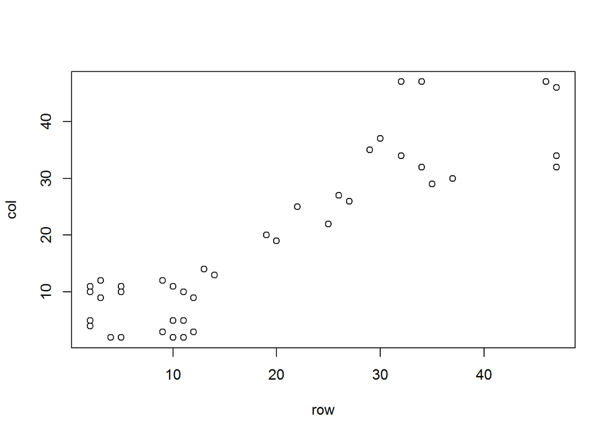

```r
plot(which(M > 0.8, arr.ind = TRUE))
```

```r
set.seed(123)
prePr <- preProcess(trainingStdNzv, method = "pca", pcaComp = 20)
trainingStdNzvPca <- predict(prePr, trainingStdNzv)

vars = apply(prePr$rotation, 2, var)
props <- vars / sum(vars)
cumsum(props)
```

```
##        PC1        PC2        PC3        PC4        PC5        PC6
## 0.05128591 0.10135170 0.15251157 0.20256433 0.25355572 0.30185549
##        PC7        PC8        PC9       PC10       PC11       PC12
## 0.35314026 0.40045449 0.45037161 0.50075380 0.54877545 0.59981686
##       PC13       PC14       PC15       PC16       PC17       PC18
## 0.64660515 0.69789457 0.74586483 0.79714591 0.84762917 0.89847246
##       PC19       PC20
## 0.94881452 1.00000000
```

Perform crossvalidation with gradient boosting

```r
library(nnet); library(gbm);library(fastAdaboost);library(ada)

set.seed(123)
fitControl <- trainControl(method = "repeatedcv",
                           number = 5,
                           repeats = 1)

set.seed(123)
fit1 <- train(classe ~ ., data=trainingStdNzvPca, method = "gbm",
                 trControl = fitControl,
                 verbose = FALSE)

set.seed(123)
predictfit1<- predict(fit1, trainingStdNzvPca)
confusionMatrix(predictfit1, trainingStdNzvPca$classe)[2]
```

```
## $table
##           Reference
## Prediction    A    B    C    D    E
##          A 3725  222  119   72   92
##          B   91 2256  158   94  144
##          C  125  260 2210  231  122
##          D  205   75   61 1971   94
##          E   39   35   19   44 2254
```

```r
# Results not fully accurate on training set
```

Perform cross validation with random forest

```r
library(randomForest)
set.seed(123)
fit2 <- randomForest(classe ~.,
              data = trainingStdNzvPca
              ,ntree=1000,
              importance=TRUE,
              trControl = fitControl
              )

predictfit2<- predict(fit2, trainingStdNzvPca)
confusionMatrix(predictfit2, trainingStdNzvPca$classe)[2]
```

```
## $table
##           Reference
## Prediction    A    B    C    D    E
##          A 4185    0    0    0    0
##          B    0 2848    0    0    0
##          C    0    0 2567    0    0
##          D    0    0    0 2412    0
##          E    0    0    0    0 2706
```

```r
#Results accurate on training set
```

Verify models using testing set

```r
testing1 <- testing[,-c(1,2,3,4,5,6)]
testing2 <- testing1[,-IndicesNA]
testingStd <- predict(preObjScale, testing2)
testingStdNzv <- testingStd[, which(nzv==FALSE)]
testingStdNzvPca <- predict(prePr, testingStdNzv)

predictfit1Test <- predict(fit1,testingStdNzvPca)
confusionMatrix(predictfit1Test, testingStdNzvPca$classe)[3]
```

```
## $overall
##       Accuracy          Kappa  AccuracyLower  AccuracyUpper   AccuracyNull
##   7.942496e-01   7.399212e-01   7.826599e-01   8.054880e-01   2.844617e-01
## AccuracyPValue  McnemarPValue
##   0.000000e+00   1.381701e-24
```

```r
predictfit2Test <- predict(fit2,testingStdNzvPca)
confusionMatrix(predictfit2Test, testingStdNzvPca$classe)[3]
```

```
## $overall
##       Accuracy          Kappa  AccuracyLower  AccuracyUpper   AccuracyNull
##   9.753263e-01   9.687899e-01   9.705892e-01   9.794852e-01   2.844617e-01
## AccuracyPValue  McnemarPValue
##   0.000000e+00   1.484962e-06
```

Accuracy on test data: 1.) 79.4% for crossvalidation with gradient boosting and  
2.) 97.5% cross validation with random forest

Use random forest model on 20 different test cases

```r
Dat3 <- Dat2[,-c(1,2,3,4,5,6)]
Dat4 <- Dat3[,-IndicesNA]
Dat5 <- predict(preObjScale, Dat4)
Dat6 <- Dat5[, which(nzv==FALSE)]
Dat7 <- predict(prePr, Dat6)

predictfitDat7 <- predict(fit2,Dat7)
predictfitDat7
```

```
##  1  2  3  4  5  6  7  8  9 10 11 12 13 14 15 16 17 18 19 20
##  B  A  B  A  A  E  D  B  A  A  B  C  B  A  E  E  A  B  B  B
## Levels: A B C D E
```

Results above for 20 different cases as shown